# 金价暴涨，私人投资者应该投资黄金吗？ ——基于 GARCH 模型族的金价波动率分析

狗熊会

2024-06-13

# 案例背景

黄金价格一直是金融市场的重要指标，其价格波动性可以反映市场情绪和宏观经济环境的变化。本案例以黄金价格为研究对象，旨在通过时间序列模型（ARCH、GARCH、EGARCH）分析黄金价格的波动特性，尤其是在疫情前后黄金价格波动的变化。

# 学习目标

1. 时间序列数据的处理与可视化。
2. 平稳性与纯随机性检验，ARCH检验的实施及解释。
3. ARCH、GARCH 和 EGARCH 模型的建立与效果评估。
4. 不同模型对波动率预测的对比分析。
5. 应用时间序列模型分析特定事件对波动率的影响。

# 准备工作

```r
## 清除工作环境
cat("\014");rm(list=ls())
```

```r
## 加载程序包
library(readxl)
library(quantmod)
library(tseries)
library(rugarch)
library(car)
library(fGarch, quietly = TRUE)
library(FinTS)
library(xts)
library(forecast)
```

```r
library(ggplot2)
library(knitr)
```

# 任务一

数据预处理。在本任务中，我们将导入并预处理黄金价格数据，转换为时间序列格式，并分析其对数收益率。通过这些操作，您将掌握时间序列数据的加载与基础可视化技能。

## 数据导入

- 从 price_daily.csv 文件中读取黄金价格数据。
- 确保数据的时间列（Date）为标准时间格式。
- 将黄金价格列（Price）转换为数值型数据，方便后续计算。
- 使用 xts 包将黄金价格数据转换为时间序列格式。

```r
# 从CSV文件中读取数据
data <- read.csv("price_daily.csv")  # 导入金价数据
data <- as.data.frame(data)          # 确保数据为数据框格式

# 转换日期列为标准时间格式
data$Date <- as.Date(data$Date, format = "%m/%d/%Y")  # 日期格式化

# 将价格列转换为数值型
data$Price <- as.numeric(gsub("[, ]", "", data$Price))  # 移除千分位符并转换为数值型

# 使用xts包将数据转化为时间序列
xts_gold <- xts(data$Price, order.by = data$Date)  # 将价格按日期排列为时间序列
```

## 黄金价格时间序列图

我们对疫情前（2014年至2019年）与疫情后（2020年至2024年）的数据进行分析，黄金价格在这段时间内总体呈现出长期上升的趋势，但在短期内也表现出显著的波动性。

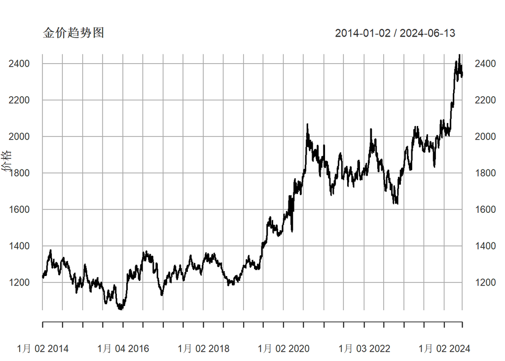

```r
# 绘制黄金价格趋势图
plot(xts_gold, main = "金价趋势图", xlab = "时间", ylab = "价格")  # 绘制时间序列图
```

## 黄金价格对数收益率

为了更有效地分析金价的动态变化，我们选择使用黄金价格的对数收益率$r_t=\ln(P_t)-\ln(P_{t-1})$来进行建模。黄金价格的对数收益率序列显示出较为平稳的特性。

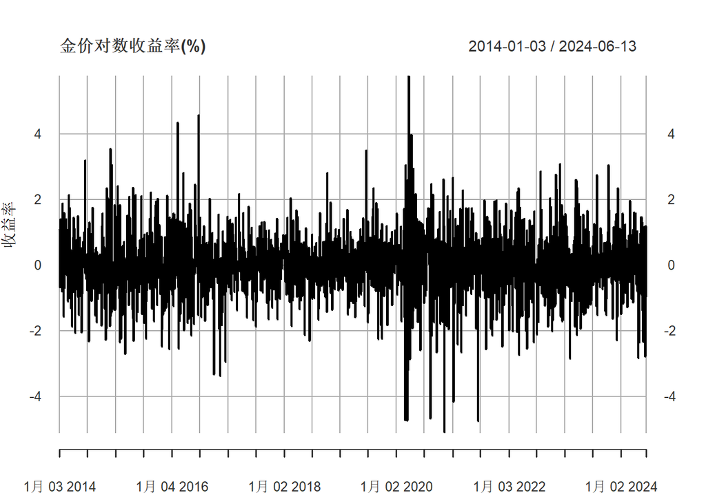

```r
# 计算对数收益率
log_return <- diff(log(xts_gold)) * 100  # 计算对数收益率并放大百分比
log_return <- log_return[-1, ]           # 去除第一个NA值

# 绘制对数收益率时间序列图
plot(log_return, main = "金价对数收益率(%)", xlab = "时间", ylab = "收益率")  # 绘制收益率图
```

# 任务二

在时间序列建模中，平稳性和纯随机性是关键属性。只有数据平稳且模型显著时，才能进行合理的建模。本任务旨在通过平稳性检验、纯随机性检验和ARCH效应检验，为后续模型选择提供依据。

## 平稳性检验

- 使用PP检验（Phillips-Perron Test），原假设为数据不平稳。
- 检验结果若显著拒绝原假设，则序列为平稳序列。

检验结果表明可以拒绝原假设，即对数收益率序列平稳，因此可以建立模型进行分析

```r
# 使用PP检验验证平稳性
pp.test(log_return)  # 原假设：对数收益率序列不平稳
```

```
##
##  Phillips-Perron Unit Root Test
##
## data:  log_return
## Dickey-Fuller Z(alpha) = -2686.6, Truncation lag parameter = 9, p-value
## = 0.01
## alternative hypothesis: stationary
```

## 纯随机性检验

- 使用Ljung-Box检验（Box.test），原假设为无显著自相关性。
- 检验结果若不能拒绝原假设，则数据为白噪声。

在0.05水平下可以承认对数收益率为白噪声列。因此，在建模过程中，我们主要关注其波动性特征，而无需对均值进行进一步的建模。

```r
# 使用Ljung-Box检验检测序列的自相关性
Box.test(log_return, lag = 5, type = "Ljung-Box")   # 检查5阶滞后
```

```
##
##  Box-Ljung test
##
## data:  log_return
## X-squared = 4.7236, df = 5, p-value = 0.4505
```

```r
Box.test(log_return, lag = 10, type = "Ljung-Box")  # 检查10阶滞后
```

```
##
##  Box-Ljung test
##
## data:  log_return
## X-squared = 10.789, df = 10, p-value = 0.3742
```

```r
Box.test(log_return, lag = 30, type = "Ljung-Box")  # 检查30阶滞后
```

```
##
##  Box-Ljung test
##
## data:  log_return
## X-squared = 37.967, df = 30, p-value = 0.1506
```

```r
Box.test(log_return, lag = 20, type = "Ljung-Box")  # 检查20阶滞后
```

```
##
##  Box-Ljung test
##
## data:  log_return
## X-squared = 28.037, df = 20, p-value = 0.1085
```

## 绘制ACF与PACF图

使用ACF和PACF图判断序列中自相关的显著性。对数收益率序列的ACF和PACF也不存在短期截尾现象，显示为白噪声。

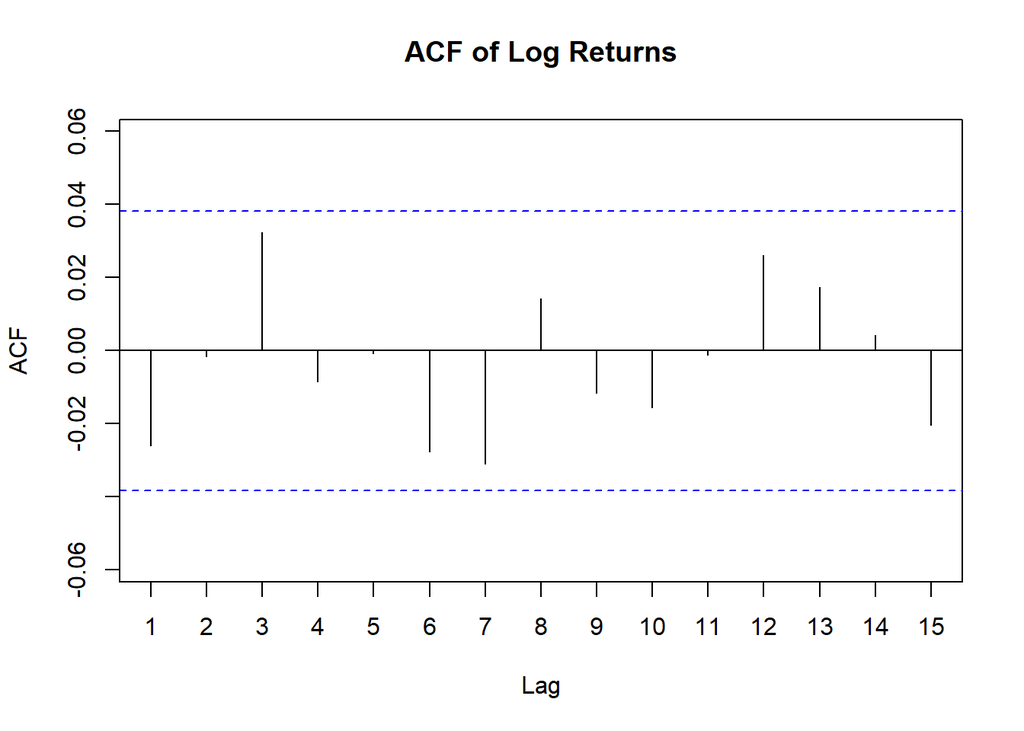

```r
# 绘制ACF图
forecast::Acf(log_return, lag.max = 15, main = "ACF of Log Returns")
```

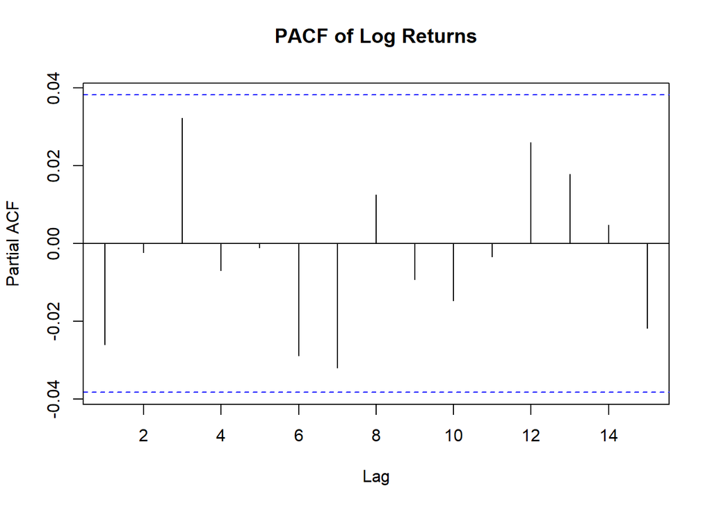

```r
# 绘制PACF图
pacf(log_return, main = "PACF of Log Returns", lag.max = 15)
```

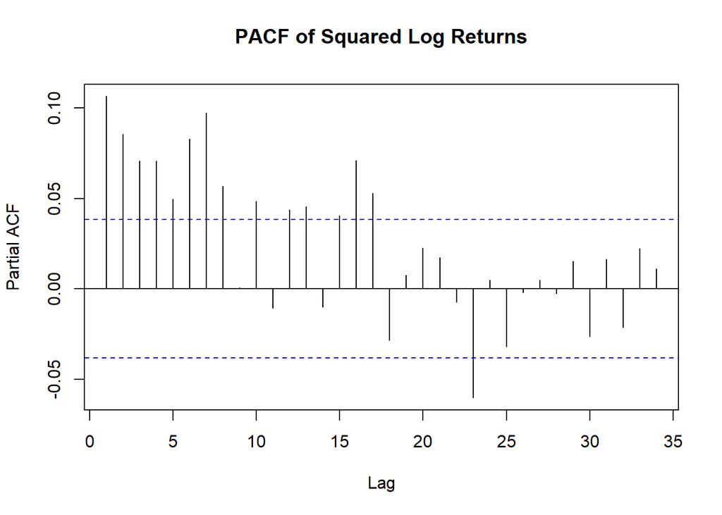

```r
# 绘制对数收益率平方的PACF
pacf(log_return^2, main = "PACF of Squared Log Returns")
```

## 分布分析

通过直方图和正态QQ图观察对数收益率的分布特性，验证是否符合正态分布。分析黄金对数收益率的分布，发现具有厚尾现象，不服从正态分布。

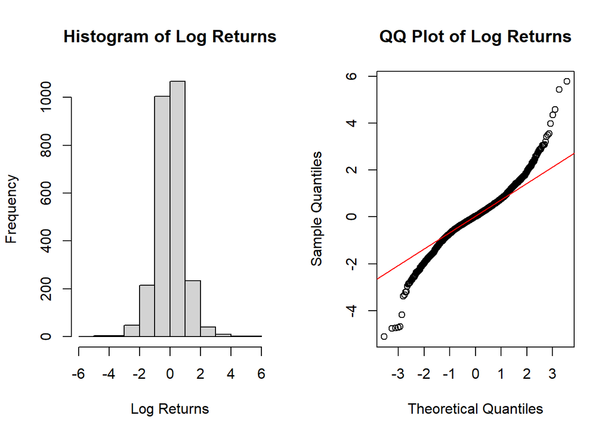

```r
par(mfrow = c(1, 2))  # 设置为1行2列布局

# 绘制对数收益率直方图
hist(log_return, main = "Histogram of Log Returns", xlab = "Log Returns")

# 绘制正态QQ图
qqnorm(log_return, main = "QQ Plot of Log Returns")  # 绘制QQ图
qqline(log_return, col = "red")                     # 添加参考线
```

## ARCH-LM 检验

绘制波动率时间序列图，通过ARCH-LM检验检测波动率的聚集效应。观察黄金对数收益率的平方(即黄金对数收益率的波动率)，发现波动率有一定的波动聚集现象，即在某些时期内波动性持续较高，而在其他时期内波动性持续较低，这种特性为后续的波动率建模提供了依据。

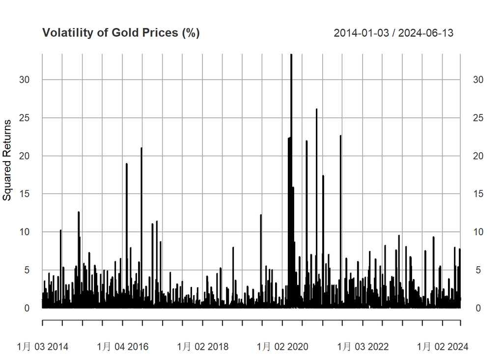

```r
# 绘制波动率时间序列图
plot(log_return^2, main = "Volatility of Gold Prices (%)", ylab = "Squared Returns")
```

```r
# 自定义ARCH-LM检验函数
archTest <- function(x, m = 10) {
  y <- (x - mean(x))^2  # 计算残差平方
  T <- length(x)        # 样本大小
  atsq <- y[(m + 1):T]
  xmat <- matrix(0, T - m, m)
  for (j in 1:m) {
    xmat[, j] <- y[(m + 1 - j):(T - j)]
  }
  lmres <- lm(atsq ~ xmat)  # 进行回归分析
  summary(lmres)            # 返回回归结果
}

# 对对数收益率序列进行ARCH-LM检验
archTest(log_return - mean(log_return), m = 20)
```

```
##
## Call:
## lm(formula = atsq ~ xmat)
##
## Residuals:
##     Min      1Q  Median      3Q     Max
## -6.6259 -0.7136 -0.4545  0.0241 25.9063
##
## Coefficients:
##              Estimate Std. Error t value Pr(>|t|)
## (Intercept)  0.334327   0.058688   5.697 1.36e-08 ***
## xmat1        0.059700   0.019644   3.039  0.00240 **
## xmat2        0.052092   0.019675   2.648  0.00816 **
## xmat3        0.037556   0.019695   1.907  0.05664 .
## xmat4        0.041227   0.019682   2.095  0.03630 *
## xmat5        0.022177   0.019705   1.125  0.26050
## xmat6        0.063114   0.019701   3.204  0.00137 **
## xmat7        0.082969   0.019728   4.206 2.69e-05 ***
## xmat8        0.045531   0.019780   2.302  0.02142 *
## xmat9       -0.017294   0.019790  -0.874  0.38226
## xmat10       0.037076   0.019787   1.874  0.06108 .
## xmat11      -0.019583   0.019787  -0.990  0.32243
## xmat12       0.034196   0.019789   1.728  0.08410 .
## xmat13       0.035827   0.019780   1.811  0.07022 .
## xmat14      -0.019631   0.019724  -0.995  0.31971
## xmat15       0.031733   0.019690   1.612  0.10716
## xmat16       0.068318   0.019719   3.465  0.00054 ***
## xmat17       0.054189   0.019748   2.744  0.00611 **
## xmat18      -0.029890   0.019764  -1.512  0.13056
## xmat19       0.006633   0.019744   0.336  0.73692
## xmat20       0.022967   0.019709   1.165  0.24399
## ---
## Signif. codes:  0 '***' 0.001 '**' 0.01 '*' 0.05 '.' 0.1 ' ' 1
##
## Residual standard error: 1.973 on 2590 degrees of freedom
## Multiple R-squared:  0.06602,    Adjusted R-squared:  0.05881
## F-statistic: 9.154 on 20 and 2590 DF,  p-value: < 2.2e-16
```

结果高度显著，说明有ARCH效应

# 任务三

在金融市场中，波动性是一个重要的研究对象，因为它可以反映市场的风险水平和投资者情绪。ARCH、GARCH 和 EGARCH 模型是描述波动性动态行为的重要工具。本任务的目标是分别使用这些模型对黄金价格的对数收益率进行建模，分析其波动性特征，并比较模型的效果。

## ARCH模型建模与分析

首先使用ARCH模型进行分析。ARCH（自回归条件异方差）模型由Robert F. Engle于1982年提出，主要用于描述金融时间序列中的波动性聚集现象。根据前一部分对ARCH效应检验的结果对ARCH模型进行定阶，拟合ARCH(8)模型，并且检查模型的拟合效果，包括残差的白噪声特性和波动率聚集现象是否被捕捉。我们发现模型能够充分捕捉黄金对数收益率的波动特性，表现为模型拟合后的残差序列为白噪声，同时残差平方序列不再具有ARCH效应。使用fGarch包中的garchFit函数进行拟合，模型拟合结果如下：

```r
# 对金价对数收益率拟合ARCH(8)模型
library(fGarch)
mod0 <- garchFit(~ 1 + garch(8, 0), data = log_return, trace = FALSE)  # ARCH(8)模型拟合
summary(mod0)  # 输出模型摘要
```

```
##
## Title:
##  GARCH Modelling
##
## Call:
##  garchFit(formula = ~1 + garch(8, 0), data = log_return, trace = FALSE)
##
## Mean and Variance Equation:
##  data ~ 1 + garch(8, 0)
## <environment: 0x00000272587b80c8>
##  [data = log_return]
##
## Conditional Distribution:
##  norm
##
## Coefficient(s):
##        mu      omega     alpha1     alpha2     alpha3     alpha4     alpha5
## 0.0422192  0.5639565  0.0011157  0.0746587  0.0914337  0.0317718  0.0071133
##    alpha6     alpha7     alpha8
## 0.0227549  0.0385111  0.0619378
##
## Std. Errors:
##  based on Hessian
##
## Error Analysis:
##         Estimate  Std. Error  t value Pr(>|t|)
## mu      0.042219    0.017217    2.452 0.014202 *
## omega   0.563957    0.029786   18.934  < 2e-16 ***
## alpha1  0.001116    0.013577    0.082 0.934506
## alpha2  0.074659    0.020397    3.660 0.000252 ***
## alpha3  0.091434    0.024612    3.715 0.000203 ***
## alpha4  0.031772    0.020069    1.583 0.113388
## alpha5  0.007113    0.016603    0.428 0.668339
## alpha6  0.022755    0.015451    1.473 0.140827
## alpha7  0.038511    0.018272    2.108 0.035066 *
## alpha8  0.061938    0.022956    2.698 0.006973 **
## ---
## Signif. codes:  0 '***' 0.001 '**' 0.01 '*' 0.05 '.' 0.1 ' ' 1
##
## Log Likelihood:
##  -3448.625    normalized:  -1.310766
##
## Description:
##  Fri Dec 20 12:08:44 2024 by user: vvddu
##
##
## Standardised Residuals Tests:
##                                   Statistic   p-Value
##  Jarque-Bera Test   R    Chi^2  670.4529820 0.0000000
##  Shapiro-Wilk Test  R    W        0.9722057 0.0000000
##  Ljung-Box Test     R    Q(10)   10.0887495 0.4327418
##  Ljung-Box Test     R    Q(15)   11.0630603 0.7481114
##  Ljung-Box Test     R    Q(20)   21.6220913 0.3613639
##  Ljung-Box Test     R^2  Q(10)    6.1985767 0.7983128
##  Ljung-Box Test     R^2  Q(15)   10.9755501 0.7543256
##  Ljung-Box Test     R^2  Q(20)   21.9685341 0.3422205
##  LM Arch Test       R    TR^2     6.4221213 0.8933273
##
## Information Criterion Statistics:
##      AIC      BIC      SIC     HQIC
## 2.629134 2.651464 2.629105 2.637220
```

然而我们注意到，ARCH模型在拟合时通常需要更高的阶数（比如我们这里选择了ARCH(8)进行拟合），这使得模型的待估参数过多，对数据量有更高的要求。同时容易产生过拟合等问题，不利于泛化。

## GARCH

为了解决ARCH模型的复杂性问题，我们进一步考虑GARCH模型。Bollerslev在1986年提出了GARCH模型，它结合了短期和长期的波动信息，可以在较低阶数下更有效地捕捉时间序列中的波动性特征。GARCH(m,s)模型的形式如下，可以看到模型分析了前m期收益率数据及前s期波动率数据对当期波动的影响。

$$\delta_t^2=\alpha_0+\sum_{i=1}^{m}{\alpha_ia}_{t-i}^2\
+\sum_{j=1}^{s}{\beta_j\delta}_{t-j}^2$$

在本案例中，我们拟合了GARCH(1，1)模型，并且分别假设残差服从标准正态分布和标准t分布，比较两种残差分布假设（正态分布和t分布）的效果。

### 残差假设为正态分布

```r
# 对金价对数收益率拟合GARCH(1,1)模型（正态分布残差假设）
mod1 <- garchFit(~ 1 + garch(1, 1), data = log_return, trace = FALSE)
summary(mod1)  # 输出模型摘要
```

```
##
## Title:
##  GARCH Modelling
##
## Call:
##  garchFit(formula = ~1 + garch(1, 1), data = log_return, trace = FALSE)
##
## Mean and Variance Equation:
##  data ~ 1 + garch(1, 1)
## <environment: 0x000002725d773ed0>
##  [data = log_return]
##
## Conditional Distribution:
##  norm
##
## Coefficient(s):
##        mu      omega     alpha1      beta1
## 0.0162176  0.0069605  0.0219677  0.9698961
##
## Std. Errors:
##  based on Hessian
##
## Error Analysis:
##         Estimate  Std. Error  t value Pr(>|t|)
## mu      0.016218    0.016808    0.965   0.3346
## omega   0.006961    0.002590    2.687   0.0072 **
## alpha1  0.021968    0.003705    5.929 3.05e-09 ***
## beta1   0.969896    0.005679  170.796  < 2e-16 ***
## ---
## Signif. codes:  0 '***' 0.001 '**' 0.01 '*' 0.05 '.' 0.1 ' ' 1
##
## Log Likelihood:
##  -3433.616    normalized:  -1.305061
##
## Description:
##  Fri Dec 20 12:08:44 2024 by user: vvddu
##
##
## Standardised Residuals Tests:
##                                   Statistic   p-Value
##  Jarque-Bera Test   R    Chi^2  841.9628049 0.0000000
##  Shapiro-Wilk Test  R    W        0.9702743 0.0000000
##  Ljung-Box Test     R    Q(10)   10.1600597 0.4265648
##  Ljung-Box Test     R    Q(15)   11.4615715 0.7192411
##  Ljung-Box Test     R    Q(20)   21.6206769 0.3614433
##  Ljung-Box Test     R^2  Q(10)    9.5891578 0.4772460
##  Ljung-Box Test     R^2  Q(15)   12.9159580 0.6087893
##  Ljung-Box Test     R^2  Q(20)   22.1009207 0.3350596
##  LM Arch Test       R    TR^2    10.2168989 0.5969387
##
## Information Criterion Statistics:
##      AIC      BIC      SIC     HQIC
## 2.613163 2.622095 2.613158 2.616397
```

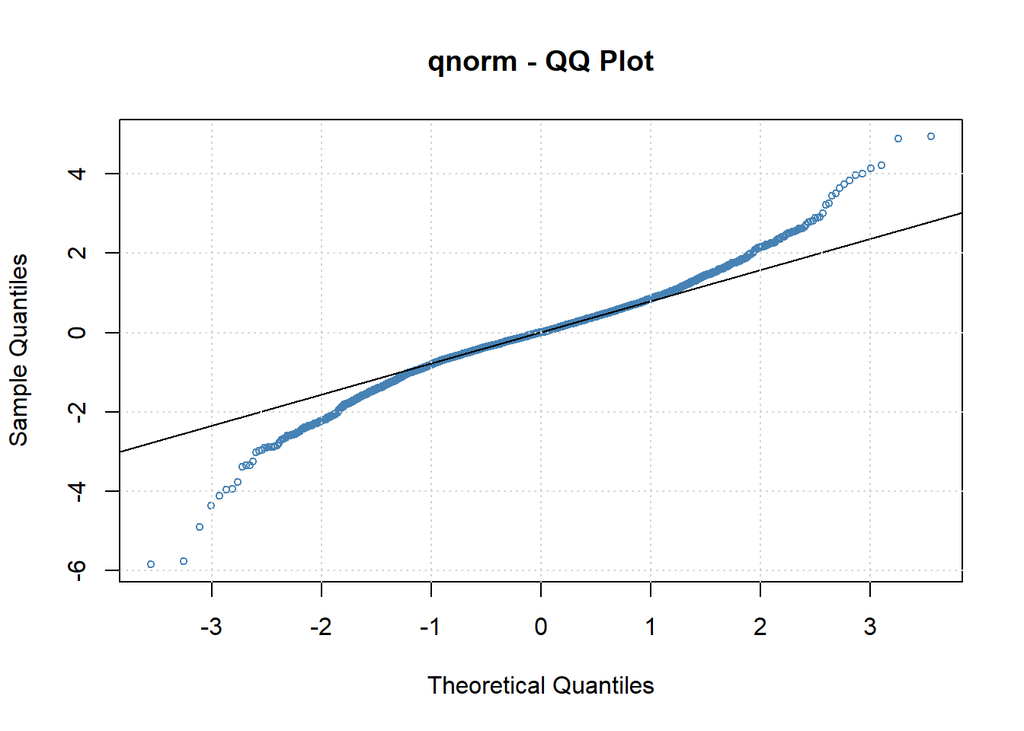

```r
# 检查模型的残差特性
plot(mod1, which = 13, main = "标准化残差的QQ图（正态分布假设）")
```

LB检验和ARCH-LM检验均说明已经不存在ARCH效应。

模型系数$\alpha+\beta=0.9918<1$满足平稳约束条件，说明过去的波动对未来的影响是逐渐衰减的。同时接近1说明过去的波动对于未来的预测有重要作用。

模型整体令人满意，但是残差不符合正态分布

### 残差假设条件t分布

```r
# 对金价对数收益率拟合GARCH(1,1)模型（t分布残差假设）
mod2 <- garchFit(~ 1 + garch(1, 1), data = log_return, cond.dist = "std", trace = FALSE)
summary(mod2)  # 输出模型摘要
```

```
##
## Title:
##  GARCH Modelling
##
## Call:
##  garchFit(formula = ~1 + garch(1, 1), data = log_return, cond.dist = "std",
##     trace = FALSE)
##
## Mean and Variance Equation:
##  data ~ 1 + garch(1, 1)
## <environment: 0x000002725f4f0dc8>
##  [data = log_return]
##
## Conditional Distribution:
##  std
##
## Coefficient(s):
##       mu     omega    alpha1     beta1     shape
## 0.025984  0.007480  0.025064  0.968084  4.127652
##
## Std. Errors:
##  based on Hessian
##
## Error Analysis:
##         Estimate  Std. Error  t value Pr(>|t|)
## mu      0.025984    0.014671    1.771   0.0765 .
## omega   0.007480    0.003204    2.334   0.0196 *
## alpha1  0.025064    0.005454    4.595 4.32e-06 ***
## beta1   0.968084    0.006845  141.431  < 2e-16 ***
## shape   4.127652    0.359426   11.484  < 2e-16 ***
## ---
## Signif. codes:  0 '***' 0.001 '**' 0.01 '*' 0.05 '.' 0.1 ' ' 1
##
## Log Likelihood:
##  -3306.376    normalized:  -1.256699
##
## Description:
##  Fri Dec 20 12:08:46 2024 by user: vvddu
##
##
## Standardised Residuals Tests:
##                                   Statistic   p-Value
##  Jarque-Bera Test   R    Chi^2  849.0954962 0.0000000
##  Shapiro-Wilk Test  R    W        0.9702192 0.0000000
##  Ljung-Box Test     R    Q(10)   10.1025105 0.4315462
##  Ljung-Box Test     R    Q(15)   11.3670577 0.7261669
##  Ljung-Box Test     R    Q(20)   21.3291693 0.3779907
##  Ljung-Box Test     R^2  Q(10)    8.6388348 0.5666876
##  Ljung-Box Test     R^2  Q(15)   11.7059918 0.7011330
##  Ljung-Box Test     R^2  Q(20)   19.9419238 0.4615679
##  LM Arch Test       R    TR^2     9.4619372 0.6630501
##
## Information Criterion Statistics:
##      AIC      BIC      SIC     HQIC
## 2.517200 2.528365 2.517192 2.521243
```

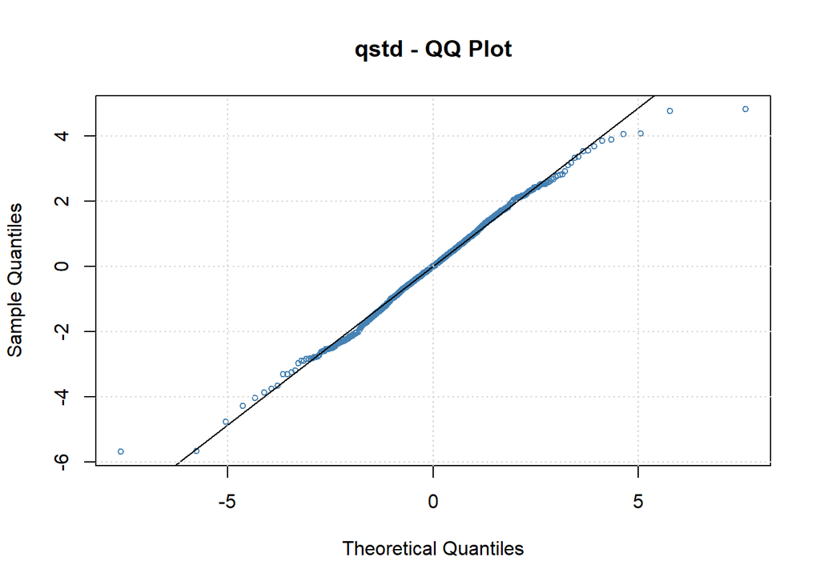

```r
# 绘制t分布假设下的QQ图
plot(mod2, which = 13, main = "标准化残差的QQ图（t分布假设）")
```

使用残差为t分布的假设的模型比残差为标准正态分布假设的模型拟合效果好。

观察模型拟合后残差相对于标准化t分布的QQ图中，可以发现残差服从t分布，说明了使用残差为条件t分布的合理性。

## EGARCH

为了进一步捕捉金价波动的非对称性，我们采用了EGARCH模型。该模型由Nelson于1991年提出，可以更好地描述所谓的“杠杆效应”，即负收益对波动率的影响可能大于正收益的情况。本案例中分析的黄金市场中通常存在明显的波动率非对称性。例如，金价通常在经济不稳定或地缘政治紧张时上涨迅速，而在市场稳定或经济增长时下跌相对缓慢。EGARCH模型的非线性特性能够更准确地捕捉这种非对称性，即所谓的杠杆效应。EGARCH(1,1)模型形式如下：

$$\ln{\delta_t^2}=\omega+\alpha_1\epsilon_{t-1}+\gamma_1(\left|\epsilon_{t-1}\right|-E|\epsilon_{t-1}|)\
+\beta_1\ln{\delta_{t-1}^2}$$

在本案例中，我们使用ugarchspec函数拟合EGARCH模型。EGARCH模型的拟合结果显示，金价的波动具有非对称性特征，即负收益和正收益对波动率的影响存在差异。EGARCH(1,1)模型拟合结果如下：

```r
# 使用EGARCH(1,1)模型拟合
library(rugarch)
spec1 <- ugarchspec(
  mean.model = list(armaOrder = c(0, 0), include.mean = TRUE),
  variance.model = list(model = "eGARCH", garchOrder = c(1, 1)),
  distribution.model = "std"  # t分布假设
)
mod3 <- ugarchfit(spec = spec1, data = log_return)  # 模型拟合
show(mod3)  # 输出模型摘要
```

```
##
## *---------------------------------*
## *          GARCH Model Fit        *
## *---------------------------------*
##
## Conditional Variance Dynamics
## -----------------------------------
## GARCH Model  : eGARCH(1,1)
## Mean Model   : ARFIMA(0,0,0)
## Distribution : std
##
## Optimal Parameters
## ------------------------------------
##         Estimate  Std. Error  t value Pr(>|t|)
## mu      0.028026    0.013913   2.0144 0.043968
## omega  -0.001378    0.001059  -1.3011 0.193212
## alpha1  0.028332    0.003309   8.5619 0.000000
## beta1   0.988013    0.002774 356.1498 0.000000
## gamma1  0.073357    0.026510   2.7672 0.005655
## shape   4.067471    0.197328  20.6127 0.000000
##
## Robust Standard Errors:
##         Estimate  Std. Error   t value Pr(>|t|)
## mu      0.028026    0.013498   2.07633 0.037864
## omega  -0.001378    0.003315  -0.41567 0.677651
## alpha1  0.028332    0.029821   0.95007 0.342078
## beta1   0.988013    0.008789 112.40909 0.000000
## gamma1  0.073357    0.076871   0.95428 0.339940
## shape   4.067471    0.809844   5.02254 0.000001
##
## LogLikelihood : -3302.595
##
## Information Criteria
## ------------------------------------
##
## Akaike       2.5151
## Bayes        2.5285
## Shibata      2.5151
## Hannan-Quinn 2.5199
##
```

[output cut: 43 more lines]

```
## Negative Sign Bias  0.4513 0.6518
## Positive Sign Bias  1.2678 0.2050
## Joint Effect        1.8420 0.6058
##
##
## Adjusted Pearson Goodness-of-Fit Test:
## ------------------------------------
##   group statistic p-value(g-1)
## 1    20     14.56       0.7503
## 2    30     25.00       0.6784
## 3    40     28.32       0.8968
## 4    50     59.14       0.1522
##
##
## Elapsed time : 0.622977
```

# 任务四

使用ARCH, GARCH, EGARCH模型预测黄金价格波动率。在金融市场中，预测波动率是理解和管理市场风险的关键。ARCH、GARCH 和 EGARCH模型可以帮助我们预测市场的未来波动率。在本任务中，我们利用这三种模型对黄金价格的波动率进行建模和预测，并通过均方误差（MSE）来评估模型的预测效果。

## 预测效果图

操作步骤如下：

1. 数据准备与训练集划分

使用历史数据的前9年（假设每年252个交易日）作为训练集，后续的数据作为测试集。

2. 模型拟合

使用训练数据，分别拟合ARCH(8)、GARCH(1,1), EGARCH(1,1)模型。

3. 波动率预测

使用拟合的模型在测试集上对波动率进行预测。

4. 结果展示

绘制训练数据和测试数据的波动率拟合及预测图。

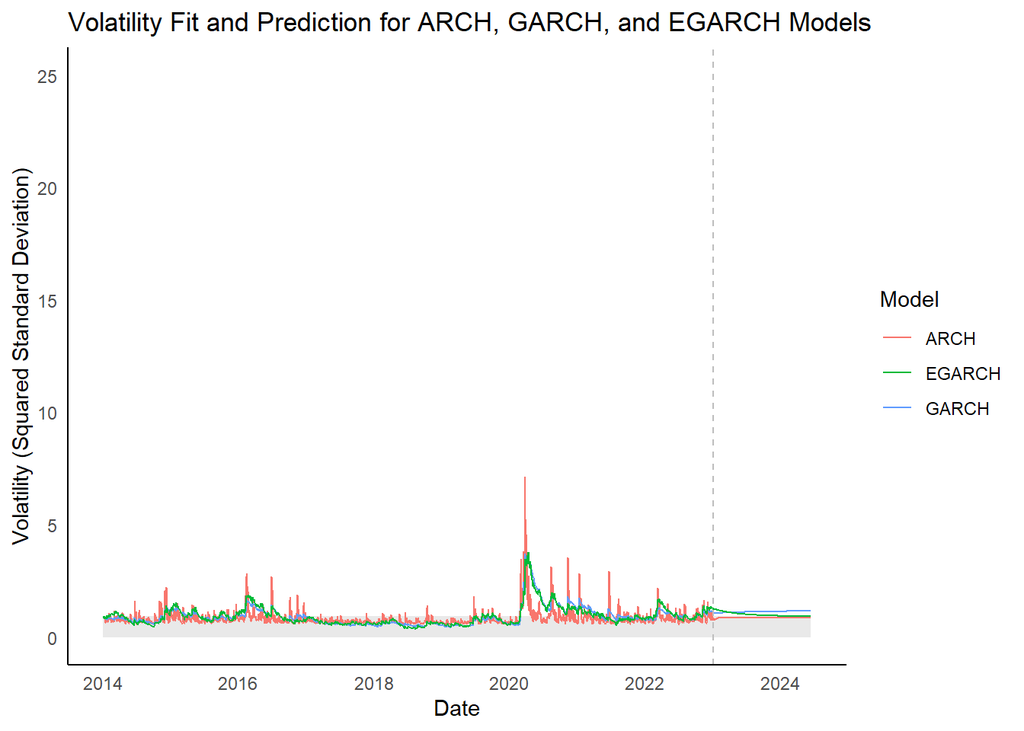

```r
train_length <- 9 * 252  # 9年的日频数据，假设每年252个交易日
train <- log_return[1:train_length]
test <- log_return[(train_length + 1):length(log_return)]

train_length <- length(train)
test_length <- length(test)

# ARCH(8,0) 模型拟合
arch_model <- garchFit(~ 1 + garch(8,0), data=train, trace=FALSE)
fitted_arch <- arch_model@sigma.t^2  # 提取训练数据的拟合波动率（平方）
predicted_arch <- predict(arch_model, n.ahead=test_length)$standardDeviation^2  # 测试集预测波动率（平方）

# GARCH(1,1) 模型拟合
garch_model <- garchFit(~ 1 + garch(1,1), data=train, cond.dist="std", trace=FALSE)
fitted_garch <- garch_model@sigma.t^2  # 提取训练数据的拟合波动率（平方）
predicted_garch <- predict(garch_model, n.ahead=test_length)$standardDeviation^2  # 测试集预测波动率（平方）

# EGARCH(1,1) 模型拟合
egarch_spec <- ugarchspec(
  mean.model = list(armaOrder=c(0,0), include.mean=TRUE),
  variance.model = list(model="eGARCH", garchOrder=c(1,1)),
  distribution.model="std"
)
egarch_model <- ugarchfit(spec=egarch_spec, data=train)
fitted_egarch <- sigma(egarch_model)^2  # 提取训练数据的拟合波动率（平方）
predicted_egarch <- sigma(ugarchforecast(egarch_model, n.ahead=test_length))^2  # 测试集预测波动率（平方）

# 合并所有模型的波动率拟合值和预测值
combined_data <- data.frame(
  Date = c(index(train), index(test)),
  ARCH_Volatility = c(fitted_arch, predicted_arch),
  GARCH_Volatility = c(fitted_garch, predicted_garch),
  EGARCH_Volatility = c(as.numeric(fitted_egarch), as.numeric(predicted_egarch))
)
Original_Volatility <- sd(log_return)

# 绘制图形
ggplot(combined_data, aes(x=Date)) +
  # 添加原波动率区域填充（透明灰色）
  geom_ribbon(aes(ymin=0, ymax=Original_Volatility), fill="lightgrey", alpha=0.5) +

  # 绘制ARCH, GARCH, EGARCH的波动率线条
  geom_line(aes(y=ARCH_Volatility, color="ARCH")) +
  geom_line(aes(y=GARCH_Volatility, color="GARCH")) +
  geom_line(aes(y=EGARCH_Volatility, color="EGARCH")) +

  # 添加拟合和预测的分割线，假设split_date为交接日期
  geom_vline(xintercept = as.Date("2023-01-04"), linetype="dashed", color="gray") +

  # 设置y轴的最大刻度
  scale_y_continuous(limits=c(0, 25)) +

  # 添加标题和标签
  labs(title="Volatility Fit and Prediction for ARCH, GARCH, and EGARCH Models",
       y="Volatility (Squared Standard Deviation)",
       color="Model") +

  # 去掉网格线，添加坐标轴线
  theme_minimal() +
  theme(panel.grid.minor = element_blank(),  # 移除次网格线
        panel.grid.major = element_blank(),  # 移除主网格线
        axis.line = element_line(colour = "black"))  # 添加坐标轴线
```

## MSE

通过测试数据上波动率的真实值和预测值计算模型预测的MSE,比较三种模型的预测效果。

```r
# 计算的MSE的函数
calculate_mse <- function(actual, predicted) {
  mse <- mean((actual - predicted)^2)
  return(mse)
}

# 计算每个模型的MSE
mse_arch <- calculate_mse(test, predicted_arch)  # ARCH模型的MSE
mse_garch <- calculate_mse(test, predicted_garch)  # GARCH模型的MSE
mse_egarch <- calculate_mse(test, predicted_egarch)  # EGARCH模型的MSE

# 创建数据框来存储结果
mse_table <- data.frame(
  Model = c("ARCH(8,0)", "GARCH(1,1)", "EGARCH(1,1)"),
  MSE = c(mse_arch, mse_garch, mse_egarch)
)

# 显示表格
kable(mse_table, caption = "MSE Comparison for Volatility Models")
```

MSE Comparison for Volatility Models

| Model | MSE |
| --- | --- |
| ARCH(8,0) | 1.383330 |
| GARCH(1,1) | 1.899583 |
| EGARCH(1,1) | 1.660124 |

# 任务五

应用EGARCH模型分析疫情对黄金价格波动率的影响。新冠疫情爆发对全球经济产生了深远的影响，金融市场特别是黄金市场的波动性也发生了显著变化。为了深入探讨疫情对黄金价格波动率的影响，我们选择使用EGARCH模型分别对疫情前（2014年至2019年）和疫情后（2020年至2024年）黄金价格的波动性进行分析，并对比两段时期的波动性特征。

### 数据划分

- 选择2014年1月1日至2019年6月1日的黄金价格对数收益率数据作为疫情前的数据。
- 选择2020年1月1日至2024年6月1日的黄金价格对数收益率数据作为疫情后的数据。

```r
after <- log_return["2020-01-01/2024-06-01"]
before <- log_return["2014-01-01/2019-06-01"]
```

### 建立EGARCH模型

对疫情前后的数据分别建立EGARCH(1,1)模型。EGARCH模型可以有效捕捉波动率的非对称性以及波动聚集效应，这对于理解疫情后的市场波动尤为重要。

```r
# 疫情前EGARCH模型拟合

spec1 <- ugarchspec(
  mean.model = list(
    armaOrder=c(0,0),
    include.mean=TRUE  ),
  variance.model = list(
    model = "eGARCH", # exponential GARCH model
    garchOrder = c(1,1) ) )
before_mod2 <- ugarchfit(spec = spec1, data =before)
show(before_mod2)
```

```
##
## *---------------------------------*
## *          GARCH Model Fit        *
## *---------------------------------*
##
## Conditional Variance Dynamics
## -----------------------------------
## GARCH Model  : eGARCH(1,1)
## Mean Model   : ARFIMA(0,0,0)
## Distribution : norm
##
## Optimal Parameters
## ------------------------------------
##         Estimate  Std. Error     t value Pr(>|t|)
## mu      0.004880    0.021241     0.22975 0.818282
## omega   0.001043    0.000502     2.07755 0.037751
## alpha1 -0.008871    0.006885    -1.28832 0.197633
## beta1   0.999759    0.000015 66115.35355 0.000000
## gamma1  0.026105    0.000557    46.89216 0.000000
##
## Robust Standard Errors:
##         Estimate  Std. Error     t value Pr(>|t|)
## mu      0.004880    0.020647     0.23637  0.81315
## omega   0.001043    0.000624     1.67258  0.09441
## alpha1 -0.008871    0.010197    -0.86989  0.38436
## beta1   0.999759    0.000018 55638.74784  0.00000
## gamma1  0.026105    0.000577    45.26217  0.00000
##
## LogLikelihood : -1636.092
##
## Information Criteria
## ------------------------------------
##
## Akaike       2.4098
## Bayes        2.4290
## Shibata      2.4098
## Hannan-Quinn 2.4170
##
## Weighted Ljung-Box Test on Standardized Residuals
## ------------------------------------
```

[output cut: 40 more lines]

```
## Negative Sign Bias  1.6695 0.09524   *
## Positive Sign Bias  1.7423 0.08168   *
## Joint Effect        6.5061 0.08942   *
##
##
## Adjusted Pearson Goodness-of-Fit Test:
## ------------------------------------
##   group statistic p-value(g-1)
## 1    20     73.36    2.520e-08
## 2    30     78.88    1.687e-06
## 3    40    100.79    2.273e-07
## 4    50    113.26    5.333e-07
##
##
## Elapsed time : 0.349601
```

```r
# 疫情后EGARCH模型拟合

spec1 <- ugarchspec(
  mean.model = list(
    armaOrder=c(0,0),
    include.mean=TRUE  ),
  variance.model = list(
    model = "eGARCH", # exponential GARCH model
    garchOrder = c(1,1) ) )
after_mod2 <- ugarchfit(spec = spec1, data =after)
show(after_mod2)
```

```
##
## *---------------------------------*
## *          GARCH Model Fit        *
## *---------------------------------*
##
## Conditional Variance Dynamics
## -----------------------------------
## GARCH Model  : eGARCH(1,1)
## Mean Model   : ARFIMA(0,0,0)
## Distribution : norm
##
## Optimal Parameters
## ------------------------------------
##         Estimate  Std. Error  t value Pr(>|t|)
## mu      0.025024    0.031403  0.79688 0.425520
## omega   0.009988    0.005619  1.77747 0.075491
## alpha1  0.032233    0.020029  1.60934 0.107542
## beta1   0.941715    0.029268 32.17594 0.000000
## gamma1  0.134626    0.036548  3.68355 0.000230
##
## Robust Standard Errors:
##         Estimate  Std. Error  t value Pr(>|t|)
## mu      0.025024    0.034510  0.72514 0.468369
## omega   0.009988    0.009997  0.99907 0.317762
## alpha1  0.032233    0.030653  1.05153 0.293014
## beta1   0.941715    0.041879 22.48639 0.000000
## gamma1  0.134626    0.063764  2.11131 0.034745
##
## LogLikelihood : -1581.527
##
## Information Criteria
## ------------------------------------
##
## Akaike       2.8535
## Bayes        2.8760
## Shibata      2.8534
## Hannan-Quinn 2.8620
##
## Weighted Ljung-Box Test on Standardized Residuals
## ------------------------------------
```

[output cut: 40 more lines]

```
## Negative Sign Bias  0.4752 0.6347
## Positive Sign Bias  1.1337 0.2572
## Joint Effect        2.5886 0.4595
##
##
## Adjusted Pearson Goodness-of-Fit Test:
## ------------------------------------
##   group statistic p-value(g-1)
## 1    20     78.76    3.045e-09
## 2    30     86.76    1.138e-07
## 3    40     99.51    3.425e-07
## 4    50    124.96    1.457e-08
##
##
## Elapsed time : 0.09559107
```

### 模型分析

我们发现，疫情后𝛽₁的值显著下降，而𝛼₁的值大幅上升，说明疫情后短期影响因素对黄金收益率序列的波动贡献度提升，黄金价格的稳定性有所下降。

疫情前𝛼₁符号为负，说明收益率下降会引起更大的波动，这符合我们对金融产品波动性规律的经验。疫情后𝛼₁系数符号为正，违反了经验，推测原因是疫情爆发的社会因素对金价波动性产生了显著的影响，掩盖了金价数据波动性原本的杠杆效应。

通过EGARCH模型，我们不仅能对疫情前后的波动率变化进行量化分析，还能更好地理解在特殊经济事件（如新冠疫情）下市场波动的结构变化。